# CSE391 programming for data science

# Midterm 1

# March 26th,2018

# Part 1

1- Download the file named data_set in the Assignment section on Blackboard and save it in a file. Then read data_set as a DataFram into python and show the first 10 rows of the data.

2- What is the shape of the DataFrame, i.e., the number of columns and rows?

3- Are there any missing value in the data? if yes how many per column? write a python script to print the number of missing values per column.

4- Remove all rows in which at least there is one missing value. Name the new Dataframe as CleanData in which there is no missing values.

5- Make a scatter plot showing the distribution of data in column 6 and 7, i.e X and Y

6- From CleanData, create a Series whose index and data are the first and seventh columns of CleanData, respectively.

7- Plot the 100 first values of series. In this plot , the x and y axes the date and the value at the date respectively .

8- Generate a pivot table in which we make a summary in terms of both Category and PdDistrict

```python
#1
import pandas as pd
data = pd.read_csv("/Users/arkwl/Desktop/data_set.csv")
x = pd.DataFrame(data)
x.head(10)
```

|  | Dates | Category | Descript | PdDistrict | Address | X | Y |
| --- | --- | --- | --- | --- | --- | --- | --- |
| 0 | 2014-12-28 23:30:00 | LARCENY/THEFT | GRAND THEFT PICKPOCKET | MISSION | 4100 Block of 18TH ST | -122.435563 | 37.760801 |
| 1 | 2014-12-28 23:30:00 | LARCENY/THEFT | GRAND THEFT FROM LOCKED AUTO | NaN | NaN | NaN | NaN |
| 2 | 2014-12-28 23:30:00 | VEHICLE THEFT | STOLEN AUTOMOBILE | CENTRAL | 500 Block of GEARY ST | -122.412777 | 37.786834 |
| 3 | 2014-12-28 23:30:00 | ASSAULT | AGGRAVATED ASSAULT WITH A DEADLY WEAPON | NORTHERN | 0 Block of ROSE ST | -122.421702 | 37.773641 |
| 4 | 2014-12-28 23:30:00 | ASSAULT | INFLICT INJURY ON COHABITEE | NORTHERN | 0 Block of ROSE ST | -122.421702 | 37.773641 |
| 5 | 2014-12-28 23:30:00 | ASSAULT | THREATS AGAINST LIFE | NaN | NaN | NaN | NaN |
| 6 | 2014-12-28 23:30:00 | WARRANTS | WARRANT ARREST | NORTHERN | 0 Block of ROSE ST | -122.421702 | 37.773641 |
| 7 | 2014-12-28 23:30:00 | ASSAULT | BATTERY, FORMER SPOUSE OR DATING RELATIONSHIP | NORTHERN | 0 Block of ROSE ST | -122.421702 | 37.773641 |
| 8 | 2014-12-28 23:28:00 | ASSAULT | BATTERY, FORMER SPOUSE OR DATING RELATIONSHIP | BAYVIEW | 800 Block of JAMESTOWN AV | -122.391150 | 37.717223 |
| 9 | 2014-12-28 23:00:00 | LARCENY/THEFT | GRAND THEFT FROM LOCKED AUTO | CENTRAL | POST ST / JONES ST | -122.413358 | 37.787664 |

```python
#2
x.info()
```

```
<class 'pandas.core.frame.DataFrame'>
RangeIndex: 74760 entries, 0 to 74759
Data columns (total 7 columns):
Dates         71160 non-null object
Category      74760 non-null object
Descript      74760 non-null object
PdDistrict    71160 non-null object
Address       71160 non-null object
X             71160 non-null float64
Y             71160 non-null float64
dtypes: float64(2), object(5)
memory usage: 4.0+ MB
```

```python
#3
x.isnull().sum(axis=0)
```

```
Dates         3600
Category         0
Descript         0
PdDistrict    3600
Address       3600
X             3600
Y             3600
dtype: int64
```

```python
#4
CleanData = x.dropna(axis=0, thresh=5)
CleanData.head(10)
```

|  | Dates | Category | Descript | PdDistrict | Address | X | Y |
| --- | --- | --- | --- | --- | --- | --- | --- |
| 0 | 2014-12-28 23:30:00 | LARCENY/THEFT | GRAND THEFT PICKPOCKET | MISSION | 4100 Block of 18TH ST | -122.435563 | 37.760801 |
| 2 | 2014-12-28 23:30:00 | VEHICLE THEFT | STOLEN AUTOMOBILE | CENTRAL | 500 Block of GEARY ST | -122.412777 | 37.786834 |
| 3 | 2014-12-28 23:30:00 | ASSAULT | AGGRAVATED ASSAULT WITH A DEADLY WEAPON | NORTHERN | 0 Block of ROSE ST | -122.421702 | 37.773641 |
| 4 | 2014-12-28 23:30:00 | ASSAULT | INFLICT INJURY ON COHABITEE | NORTHERN | 0 Block of ROSE ST | -122.421702 | 37.773641 |
| 6 | 2014-12-28 23:30:00 | WARRANTS | WARRANT ARREST | NORTHERN | 0 Block of ROSE ST | -122.421702 | 37.773641 |
| 7 | 2014-12-28 23:30:00 | ASSAULT | BATTERY, FORMER SPOUSE OR DATING RELATIONSHIP | NORTHERN | 0 Block of ROSE ST | -122.421702 | 37.773641 |
| 8 | 2014-12-28 23:28:00 | ASSAULT | BATTERY, FORMER SPOUSE OR DATING RELATIONSHIP | BAYVIEW | 800 Block of JAMESTOWN AV | -122.391150 | 37.717223 |
| 9 | 2014-12-28 23:00:00 | LARCENY/THEFT | GRAND THEFT FROM LOCKED AUTO | CENTRAL | POST ST / JONES ST | -122.413358 | 37.787664 |
| 10 | 2014-12-28 23:00:00 | LARCENY/THEFT | GRAND THEFT FROM LOCKED AUTO | SOUTHERN | HOWARD ST / 8TH ST | -122.411610 | 37.776221 |
| 11 | 2014-12-28 23:00:00 | LARCENY/THEFT | GRAND THEFT FROM LOCKED AUTO | CENTRAL | BUSH ST / STOCKTON ST | -122.407152 | 37.790366 |

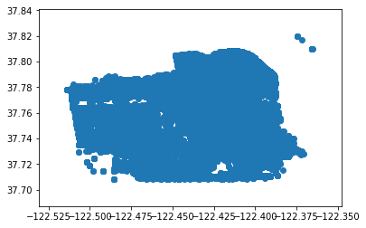

```python
#5
import matplotlib.pyplot as plt
plt.scatter(CleanData['X'], CleanData['Y'])
plt.show()
```

```python
#6- From CleanData, create a Series whose index and data are the first and seventh columns of CleanData, respectively.
S = pd.Series(CleanData['Y'].values, CleanData['Dates'] )
S.head(10)
```

```
Dates
2014-12-28 23:30:00    37.760801
2014-12-28 23:30:00    37.786834
2014-12-28 23:30:00    37.773641
2014-12-28 23:30:00    37.773641
2014-12-28 23:30:00    37.773641
2014-12-28 23:30:00    37.773641
2014-12-28 23:28:00    37.717223
2014-12-28 23:00:00    37.787664
2014-12-28 23:00:00    37.776221
2014-12-28 23:00:00    37.790366
dtype: float64
```

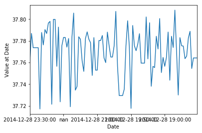

```python
#7
data = S.head(100)
data.plot()
plt.xlabel('Date')
plt.ylabel('Value at Date')
plt.show()
```

```python
#8- make a summary in terms of both Category and PdDistrict
#pivot = pd.pivot_table(CleanData, values='Address', index=['Category', 'PdDistrict'],columns=['Descript'], aggfunc='count')
pivot = pd.pivot_table(index=['Category', 'PdDistrict'], data=CleanData)
pivot
```

| Category | PdDistrict | X | Y |
| --- | --- | --- | --- |
| ARSON | BAYVIEW | -122.389389 | 37.736708 |
|  | CENTRAL | -122.408073 | 37.793609 |
|  | INGLESIDE | -122.429655 | 37.726449 |
|  | MISSION | -122.424681 | 37.759388 |
|  | NORTHERN | -122.430404 | 37.788456 |
|  | PARK | -122.447397 | 37.768208 |
|  | RICHMOND | -122.464903 | 37.782513 |
|  | SOUTHERN | -122.407227 | 37.781116 |
|  | TARAVAL | -122.475901 | 37.736729 |
|  | TENDERLOIN | -122.409963 | 37.785383 |
| ASSAULT | BAYVIEW | -122.391715 | 37.733872 |
|  | CENTRAL | -122.409907 | 37.795281 |
|  | INGLESIDE | -122.427368 | 37.724256 |
|  | MISSION | -122.419527 | 37.759833 |
|  | NORTHERN | -122.426107 | 37.785314 |
|  | PARK | -122.445499 | 37.770331 |
|  | RICHMOND | -122.472815 | 37.780162 |
|  | SOUTHERN | -122.405736 | 37.779795 |
|  | TARAVAL | -122.474953 | 37.733692 |
|  | TENDERLOIN | -122.412821 | 37.783585 |
| BAD CHECKS | BAYVIEW | -122.389864 | 37.737586 |
|  | CENTRAL | -122.404878 | 37.789866 |
|  | MISSION | -122.429377 | 37.764007 |
|  | NORTHERN | -122.420720 | 37.785101 |
|  | SOUTHERN | -122.410334 | 37.779960 |
| BRIBERY | BAYVIEW | -122.389389 | 37.739033 |
|  | INGLESIDE | -122.428640 | 37.727593 |
|  | MISSION | -122.415797 | 37.761283 |
|  | NORTHERN | -122.443520 | 37.798999 |
|  | SOUTHERN | -122.406533 | 37.780718 |
| ... | ... | ... | ... |
| VEHICLE THEFT | BAYVIEW | -122.395826 | 37.737101 |
|  | CENTRAL | -122.411764 | 37.795907 |
|  | INGLESIDE | -122.427291 | 37.728730 |
|  | MISSION | -122.420811 | 37.758205 |
|  | NORTHERN | -122.428344 | 37.788008 |
|  | PARK | -122.444589 | 37.768853 |
|  | RICHMOND | -122.467506 | 37.780925 |
|  | SOUTHERN | -122.404241 | 37.779679 |
|  | TARAVAL | -122.478440 | 37.739211 |
|  | TENDERLOIN | -122.411946 | 37.784524 |
| WARRANTS | BAYVIEW | -122.391859 | 37.737207 |
|  | CENTRAL | -122.409736 | 37.794276 |
|  | INGLESIDE | -122.428981 | 37.726437 |
|  | MISSION | -122.418871 | 37.761462 |
|  | NORTHERN | -122.424707 | 37.785748 |
|  | PARK | -122.447411 | 37.770619 |
|  | RICHMOND | -122.471798 | 37.778624 |
|  | SOUTHERN | -122.407795 | 37.778933 |
|  | TARAVAL | -122.477462 | 37.737738 |
|  | TENDERLOIN | -122.412451 | 37.783455 |
| WEAPON LAWS | BAYVIEW | -122.389977 | 37.733807 |
|  | CENTRAL | -122.409663 | 37.795122 |
|  | INGLESIDE | -122.427087 | 37.724619 |
|  | MISSION | -122.417567 | 37.758948 |
|  | NORTHERN | -122.425345 | 37.784030 |
|  | PARK | -122.444732 | 37.774416 |
|  | RICHMOND | -122.468016 | 37.778315 |
|  | SOUTHERN | -122.407105 | 37.779451 |
|  | TARAVAL | -122.474517 | 37.734175 |
|  | TENDERLOIN | -122.412698 | 37.782867 |

328 rows × 2 columns